**State-by-State Spending on Primary and Secondary Education over 20 years**

*$1000s per child adjusted for inflation*

1997

1998

1999

2000

2001

2002

2003

2004

2005

2006

2007

2008

2009

2010

2011

2012

2013

2014

2015

2016

Trend

South

Alabama

3.93

4.16

4.43

4.60

4.65

4.74

4.83

4.88

5.06

5.41

5.83

6.21

6.11

6.03

5.98

5.65

5.74

5.78

5.76

5.67

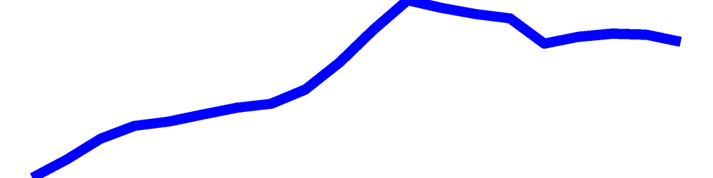

Arkansas

3.89

4.14

4.29

4.40

4.54

4.71

4.91

5.05

5.51

5.64

5.74

5.78

6.20

6.55

6.62

5.97

5.89

5.90

5.91

5.93

[figure not shown]

Delaware

5.63

5.74

5.80

6.04

6.24

6.48

6.74

6.95

7.17

7.46

7.12

7.45

7.25

7.35

7.58

8.14

8.06

8.15

8.23

8.44

[figure not shown]

Florida

4.45

4.56

4.75

4.68

4.76

4.86

5.07

5.21

5.38

5.56

5.91

6.07

5.85

5.79

5.84

5.41

5.38

5.52

5.54

5.50

[figure not shown]

Georgia

4.61

4.80

5.09

5.25

5.50

5.77

5.85

5.89

5.82

6.01

6.27

6.58

6.49

6.35

6.15

6.06

5.92

5.95

6.08

6.25

[figure not shown]

Kentucky

4.04

4.02

4.22

4.31

4.42

4.56

4.63

4.70

5.09

5.33

5.32

5.63

5.59

5.79

5.89

5.93

5.83

5.73

5.81

5.88

[figure not shown]

Louisiana

3.98

4.21

4.41

4.47

4.66

4.87

5.05

5.20

5.32

5.61

5.86

6.36

6.66

6.69

6.69

7.01

6.18

6.18

6.27

6.22

[figure not shown]

Maryland

5.07

5.10

5.34

5.43

5.75

6.10

6.20

6.27

6.44

6.77

7.30

7.78

8.06

8.16

8.06

7.91

8.04

8.08

8.20

7.33

[figure not shown]

Mississippi

3.41

3.59

3.72

4.03

4.07

4.14

4.42

4.64

4.77

5.05

5.04

5.19

5.25

5.27

5.08

5.17

5.15

5.15

5.26

5.35

[figure not shown]

North Carolina

4.22

4.41

4.60

4.89

4.91

4.99

5.01

5.01

5.20

5.19

5.40

5.34

5.69

5.51

5.26

5.16

5.17

5.07

5.20

5.19

[figure not shown]

Oklahoma

4.17

4.37

4.58

4.73

5.01

5.29

5.17

5.03

5.27

5.33

5.53

5.60

5.65

5.72

5.05

5.03

5.07

5.04

4.96

4.90

[figure not shown]

South Carolina

4.19

4.41

4.68

4.98

5.25

5.56

5.61

5.62

5.76

5.89

6.04

6.36

6.39

6.21

5.99

5.94

6.02

6.23

6.29

6.38

[figure not shown]

Tennessee

3.85

3.98

4.13

4.43

4.47

4.55

4.64

4.72

4.82

4.80

4.86

5.10

5.31

5.41

5.53

5.31

5.23

5.34

5.28

5.23

[figure not shown]

Texas

4.34

4.54

4.69

5.02

5.16

5.31

5.45

5.55

5.45

5.45

5.54

5.78

5.83

6.00

5.82

5.44

5.40

5.50

5.60

5.63

[figure not shown]

Virginia

4.98

5.33

5.43

5.95

6.10

6.30

6.36

6.36

6.69

7.00

7.29

7.51

7.52

7.46

7.24

7.18

7.23

7.33

7.42

7.28

[figure not shown]

West Virginia

5.57

5.68

6.07

6.34

6.41

6.48

6.57

6.61

6.67

6.77

6.80

6.83

7.25

7.98

7.94

7.58

7.32

7.24

7.29

7.25

[figure not shown]

Average

4.40

4.56

4.76

4.97

5.12

5.29

5.41

5.48

5.65

5.83

5.99

6.22

6.32

6.39

6.30

6.18

6.10

6.14

6.19

6.15

—

West

Alaska

7.55

7.13

7.62

7.73

7.95

8.20

8.38

8.48

8.80

9.06

9.47

10.98

11.69

11.97

11.94

11.26

11.63

11.50

12.11

10.63

[figure not shown]

Arizona

3.71

3.72

3.81

3.94

4.00

4.07

4.27

4.41

4.43

4.51

4.61

4.80

4.86

4.73

4.49

4.33

4.08

4.23

4.15

4.15

[figure not shown]

California

4.28

4.65

4.85

5.12

5.56

6.03

6.11

6.17

6.21

6.30

6.64

6.82

6.66

6.38

6.16

6.19

6.12

6.24

6.76

7.17

[figure not shown]

Colorado

4.38

4.64

4.76

4.84

5.01

5.26

5.41

5.56

5.63

5.74

5.65

6.08

5.84

5.91

5.75

5.57

5.59

5.77

5.87

6.06

[figure not shown]

Hawaii

3.23

3.45

3.87

4.18

4.85

5.52

5.95

6.26

6.21

6.51

7.04

7.19

7.43

6.38

5.82

5.48

5.37

5.98

5.54

5.72

[figure not shown]

Idaho

3.99

4.10

4.30

4.25

4.47

4.71

4.67

4.59

4.56

4.49

4.46

4.52

4.60

4.52

4.25

4.11

4.20

4.13

4.14

4.20

[figure not shown]

Montana

4.92

5.03

5.11

5.20

5.36

5.55

5.73

5.88

5.87

5.98

6.16

6.29

6.42

6.69

6.66

6.48

6.47

6.62

6.57

6.67

[figure not shown]

Nevada

4.23

4.33

4.49

4.52

4.60

4.69

4.79

4.80

4.92

5.17

5.46

5.55

5.57

5.62

5.67

5.37

5.39

5.37

5.42

5.54

[figure not shown]

New Mexico

3.96

4.16

4.47

4.66

4.90

5.13

5.37

5.54

5.59

5.76

5.92

6.08

6.20

6.14

5.85

5.63

5.64

5.59

6.03

5.86

[figure not shown]

Oregon

5.08

5.38

5.55

5.60

5.78

5.99

5.85

5.71

5.93

6.04

6.18

6.48

6.58

6.41

6.35

6.24

6.18

6.37

6.64

6.84

[figure not shown]

Utah

3.41

3.52

3.67

3.69

3.82

3.96

3.93

3.87

3.86

3.83

3.83

4.10

4.18

3.77

3.97

3.94

4.07

3.98

3.94

4.07

[figure not shown]

Washington

4.90

5.10

5.16

5.28

5.37

5.50

5.57

5.57

5.63

5.64

5.80

6.16

6.40

6.24

6.18

6.22

6.15

6.42

6.73

7.18

[figure not shown]

Wyoming

5.81

5.92

6.40

6.68

7.04

7.35

7.53

7.62

7.83

8.42

9.36

9.48

9.73

10.16

10.46

10.45

10.25

10.23

10.33

10.59

[figure not shown]

Average

4.57

4.70

4.93

5.05

5.29

5.54

5.66

5.73

5.81

5.96

6.20

6.50

6.63

6.53

6.43

6.25

6.24

6.34

6.48

6.51

—

Northeast

Connecticut

6.70

6.39

7.07

7.26

7.50

7.82

8.03

8.24

8.36

8.67

8.95

9.28

9.89

10.06

9.78

9.86

9.97

10.29

10.56

10.81

[figure not shown]

District of Columbia

6.11

7.19

7.73

9.00

9.79

10.71

11.45

12.07

12.69

12.84

12.51

16.31

17.35

18.81

17.64

17.89

17.28

16.98

17.10

17.66

[figure not shown]

Maine

5.92

6.27

6.14

6.39

6.54

6.74

7.00

7.24

7.35

7.53

7.71

7.88

8.26

8.33

8.33

8.11

7.92

8.09

8.38

8.45

[figure not shown]

Massachusetts

5.52

5.95

6.29

6.60

6.92

7.31

7.46

7.61

7.79

7.94

8.11

8.46

8.91

8.74

8.63

8.89

8.98

9.34

9.51

9.49

[figure not shown]

New Hampshire

5.06

5.22

5.36

5.66

5.93

6.25

6.60

6.93

7.15

7.38

7.64

8.09

8.46

8.81

9.01

9.15

9.22

9.40

9.63

9.82

[figure not shown]

New Jersey

7.22

7.61

7.71

8.27

8.33

8.45

9.05

9.60

9.94

10.25

10.38

10.65

10.87

11.30

10.75

10.91

11.30

11.72

11.52

11.59

[figure not shown]

New York

7.05

7.37

7.69

8.17

8.46

8.83

9.19

9.52

9.83

10.22

10.58

11.06

11.50

11.77

11.84

11.86

12.59

12.89

13.30

12.77

[figure not shown]

Pennsylvania

5.26

5.94

6.17

6.21

6.02

5.88

6.56

7.17

7.38

7.46

7.54

7.71

7.86

8.13

8.06

7.96

8.63

8.56

8.83

9.13

[figure not shown]

Rhode Island

6.06

6.33

6.47

6.67

7.04

7.45

7.88

8.30

8.39

8.57

9.09

9.30

9.48

9.57

9.56

9.59

9.80

9.79

9.96

10.20

[figure not shown]

Vermont

5.63

6.21

6.74

7.20

7.18

7.25

8.04

8.77

9.13

9.31

9.65

10.02

10.56

10.93

10.88

11.03

11.29

11.46

11.72

12.03

[figure not shown]

Average

6.05

6.45

6.74

7.14

7.37

7.67

8.13

8.55

8.80

9.02

9.22

9.88

10.31

10.65

10.45

10.52

10.70

10.85

11.05

11.20

—

North Central

Illinois

4.44

4.90

5.22

5.42

5.49

5.62

5.90

6.14

6.21

6.36

6.46

6.68

7.12

7.32

7.28

7.28

7.32

7.55

7.66

7.73

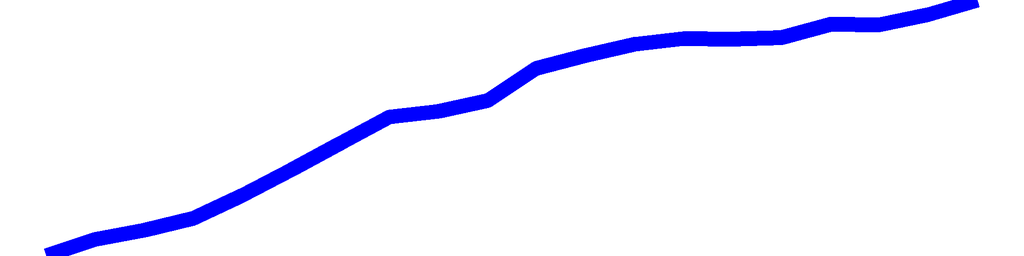

Indiana

4.55

4.80

4.91

4.97

5.10

5.27

5.50

5.68

5.94

5.75

5.76

5.50

5.61

5.72

5.46

5.40

5.23

5.15

5.16

5.20

[figure not shown]

Iowa

4.62

5.10

5.22

5.36

5.34

5.35

5.63

5.87

5.93

6.02

6.12

6.34

6.59

6.62

6.61

6.67

6.79

6.91

7.05

7.14

[figure not shown]

Kansas

4.73

4.83

4.88

5.01

5.21

5.44

5.50

5.54

5.52

5.74

5.99

6.24

6.33

6.09

6.00

5.93

5.99

6.03

6.06

6.01

[figure not shown]

Michigan

5.66

6.03

6.25

6.44

6.38

6.38

6.87

7.32

7.30

6.64

7.32

7.02

7.12

7.17

6.90

6.68

6.51

6.46

6.57

6.59

[figure not shown]

Minnesota

5.57

5.52

5.83

6.04

5.99

6.01

6.16

6.26

6.33

6.42

6.52

6.68

7.23

6.88

6.76

6.71

6.81

6.92

7.15

7.34

[figure not shown]

Missouri

4.32

4.49

4.72

4.89

5.15

5.43

5.44

5.43

5.46

5.59

5.74

5.96

6.10

6.14

5.91

5.85

5.92

5.98

6.11

6.15

[figure not shown]

Nebraska

4.71

4.71

4.74

4.91

5.21

5.52

5.66

5.75

5.68

5.73

6.05

6.15

6.43

6.86

6.84

7.05

7.15

7.18

7.29

7.47

[figure not shown]

North Dakota

4.21

4.56

4.73

4.94

5.05

5.19

5.58

5.88

6.01

6.06

6.08

6.32

6.50

6.88

7.03

6.95

6.97

7.00

7.48

7.55

[figure not shown]

Ohio

4.76

5.05

5.29

5.51

5.70

5.94

6.28

6.59

6.60

6.65

6.62

6.73

6.87

7.02

7.04

7.11

6.83

6.92

7.07

7.33

[figure not shown]

South Dakota

3.99

4.07

4.26

4.44

4.60

4.80

4.91

4.98

5.04

5.04

5.03

5.18

5.26

5.35

5.29

5.06

5.03

5.16

5.21

5.30

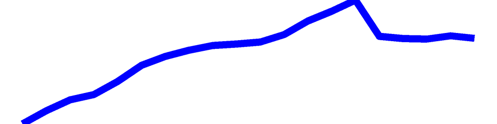

Wisconsin

5.79

6.00

6.16

6.24

6.45

6.69

6.83

6.93

7.00

7.02

7.05

7.17

7.38

7.53

7.70

7.14

7.11

7.10

7.15

7.11

[figure not shown]

Average

4.78

5.00

5.18

5.35

5.47

5.64

5.85

6.03

6.08

6.09

6.23

6.33

6.54

6.63

6.57

6.49

6.47

6.53

6.66

6.74

—

**By**: @yjunechoe  
**Inspiration**: @thomas_mock  
**Data**: Urban Institute | {tidykids} by Joshua Rosenberg